# Loans Data Exploration

## by Nashwa Shafik

- Preliminary Wrangling
- Univariate Exploration
- Bivariate Exploration
- Multivariate Exploration

## Preliminary Wrangling

This data set contains 113,937 loans with 81 variables on each loan, including loan amount, borrower rate (or interest rate), current loan status, borrower income, and many others..

```python
# import all packages and set plots to be embedded inline
import numpy as np
import pandas as pd
import matplotlib.pyplot as plt
import seaborn as sb

%matplotlib inline
```

```python
# load in the dataset into a pandas dataframe, print statistics
loans = pd.read_csv('prosperLoanData.csv')
```

```python
loans.head()
```

|  | ListingKey | ListingNumber | ListingCreationDate | CreditGrade | Term | LoanStatus | ClosedDate | BorrowerAPR | BorrowerRate | LenderYield | EstimatedEffectiveYield | EstimatedLoss | EstimatedReturn | ProsperRating (numeric) | ProsperRating (Alpha) | ProsperScore | ListingCategory (numeric) | BorrowerState | Occupation | EmploymentStatus | EmploymentStatusDuration | IsBorrowerHomeowner | CurrentlyInGroup | GroupKey | DateCreditPulled | CreditScoreRangeLower | CreditScoreRangeUpper | FirstRecordedCreditLine | CurrentCreditLines | … |
| --- | --- | --- | --- | --- | --- | --- | --- | --- | --- | --- | --- | --- | --- | --- | --- | --- | --- | --- | --- | --- | --- | --- | --- | --- | --- | --- | --- | --- | --- | --- |
| 0 | 1021339766868145413AB3B | 193129 | 2007-08-26 19:09:29.263000000 | C | 36 | Completed | 2009-08-14 00:00:00 | 0.16516 | 0.1580 | 0.1380 | NaN | NaN | NaN | NaN | NaN | NaN | 0 | CO | Other | Self-employed | 2.0 | True | True | NaN | 2007-08-26 18:41:46.780000000 | 640.0 | 659.0 | 2001-10-11 00:00:00 | 5.0 | … |
| 1 | 10273602499503308B223C1 | 1209647 | 2014-02-27 08:28:07.900000000 | NaN | 36 | Current | NaN | 0.12016 | 0.0920 | 0.0820 | 0.07960 | 0.0249 | 0.05470 | 6.0 | A | 7.0 | 2 | CO | Professional | Employed | 44.0 | False | False | NaN | 2014-02-27 08:28:14 | 680.0 | 699.0 | 1996-03-18 00:00:00 | 14.0 | … |
| 2 | 0EE9337825851032864889A | 81716 | 2007-01-05 15:00:47.090000000 | HR | 36 | Completed | 2009-12-17 00:00:00 | 0.28269 | 0.2750 | 0.2400 | NaN | NaN | NaN | NaN | NaN | NaN | 0 | GA | Other | Not available | NaN | False | True | 783C3371218786870A73D20 | 2007-01-02 14:09:10.060000000 | 480.0 | 499.0 | 2002-07-27 00:00:00 | NaN | … |
| 3 | 0EF5356002482715299901A | 658116 | 2012-10-22 11:02:35.010000000 | NaN | 36 | Current | NaN | 0.12528 | 0.0974 | 0.0874 | 0.08490 | 0.0249 | 0.06000 | 6.0 | A | 9.0 | 16 | GA | Skilled Labor | Employed | 113.0 | True | False | NaN | 2012-10-22 11:02:32 | 800.0 | 819.0 | 1983-02-28 00:00:00 | 5.0 | … |
| 4 | 0F023589499656230C5E3E2 | 909464 | 2013-09-14 18:38:39.097000000 | NaN | 36 | Current | NaN | 0.24614 | 0.2085 | 0.1985 | 0.18316 | 0.0925 | 0.09066 | 3.0 | D | 4.0 | 2 | MN | Executive | Employed | 44.0 | True | False | NaN | 2013-09-14 18:38:44 | 680.0 | 699.0 | 2004-02-20 00:00:00 | 19.0 | … |

```python
loans.info()
```

```
<class 'pandas.core.frame.DataFrame'>
RangeIndex: 113937 entries, 0 to 113936
Data columns (total 81 columns):
 #   Column                               Non-Null Count   Dtype
---  ------                               --------------   -----
 0   ListingKey                           113937 non-null  object
 1   ListingNumber                        113937 non-null  int64
 2   ListingCreationDate                  113937 non-null  object
 3   CreditGrade                          28953 non-null   object
 4   Term                                 113937 non-null  int64
 5   LoanStatus                           113937 non-null  object
 6   ClosedDate                           55089 non-null   object
 7   BorrowerAPR                          113912 non-null  float64
 8   BorrowerRate                         113937 non-null  float64
 9   LenderYield                          113937 non-null  float64
```

[output cut: 73 more lines]

```python
#Check uniqueness of ListingNumber and ListingKey to select only one of them
loans.ListingNumber.nunique(), loans.ListingKey.nunique()
```

```
(113066, 113066)
```

```python
#Check the duplicates
# loans[loans.ListingNumber.duplicated() & loans.ListingCreationDate.duplicated()]
loans[['ListingNumber','ListingCreationDate']].duplicated().sum()
```

```
871
```

```python
#Apparently the listings are duplicated with same number and creation date, so will drop duplucates
loans.drop_duplicates()
```

|  | ListingKey | ListingNumber | ListingCreationDate | CreditGrade | Term | LoanStatus | ClosedDate | BorrowerAPR | BorrowerRate | LenderYield | EstimatedEffectiveYield | EstimatedLoss | EstimatedReturn | ProsperRating (numeric) | ProsperRating (Alpha) | ProsperScore | ListingCategory (numeric) | BorrowerState | Occupation | EmploymentStatus | EmploymentStatusDuration | IsBorrowerHomeowner | CurrentlyInGroup | GroupKey | DateCreditPulled | CreditScoreRangeLower | CreditScoreRangeUpper | FirstRecordedCreditLine | CurrentCreditLines | … |
| --- | --- | --- | --- | --- | --- | --- | --- | --- | --- | --- | --- | --- | --- | --- | --- | --- | --- | --- | --- | --- | --- | --- | --- | --- | --- | --- | --- | --- | --- | --- |
| 0 | 1021339766868145413AB3B | 193129 | 2007-08-26 19:09:29.263000000 | C | 36 | Completed | 2009-08-14 00:00:00 | 0.16516 | 0.1580 | 0.1380 | NaN | NaN | NaN | NaN | NaN | NaN | 0 | CO | Other | Self-employed | 2.0 | True | True | NaN | 2007-08-26 18:41:46.780000000 | 640.0 | 659.0 | 2001-10-11 00:00:00 | 5.0 | … |
| 1 | 10273602499503308B223C1 | 1209647 | 2014-02-27 08:28:07.900000000 | NaN | 36 | Current | NaN | 0.12016 | 0.0920 | 0.0820 | 0.07960 | 0.0249 | 0.05470 | 6.0 | A | 7.0 | 2 | CO | Professional | Employed | 44.0 | False | False | NaN | 2014-02-27 08:28:14 | 680.0 | 699.0 | 1996-03-18 00:00:00 | 14.0 | … |
| 2 | 0EE9337825851032864889A | 81716 | 2007-01-05 15:00:47.090000000 | HR | 36 | Completed | 2009-12-17 00:00:00 | 0.28269 | 0.2750 | 0.2400 | NaN | NaN | NaN | NaN | NaN | NaN | 0 | GA | Other | Not available | NaN | False | True | 783C3371218786870A73D20 | 2007-01-02 14:09:10.060000000 | 480.0 | 499.0 | 2002-07-27 00:00:00 | NaN | … |
| 3 | 0EF5356002482715299901A | 658116 | 2012-10-22 11:02:35.010000000 | NaN | 36 | Current | NaN | 0.12528 | 0.0974 | 0.0874 | 0.08490 | 0.0249 | 0.06000 | 6.0 | A | 9.0 | 16 | GA | Skilled Labor | Employed | 113.0 | True | False | NaN | 2012-10-22 11:02:32 | 800.0 | 819.0 | 1983-02-28 00:00:00 | 5.0 | … |
| 4 | 0F023589499656230C5E3E2 | 909464 | 2013-09-14 18:38:39.097000000 | NaN | 36 | Current | NaN | 0.24614 | 0.2085 | 0.1985 | 0.18316 | 0.0925 | 0.09066 | 3.0 | D | 4.0 | 2 | MN | Executive | Employed | 44.0 | True | False | NaN | 2013-09-14 18:38:44 | 680.0 | 699.0 | 2004-02-20 00:00:00 | 19.0 | … |
| ... | ... | ... | ... | ... | ... | ... | ... | ... | ... | ... | ... | ... | ... | ... | ... | ... | ... | ... | ... | ... | ... | ... | ... | ... | ... | ... | ... | ... | ... | … |
| 113932 | E6D9357655724827169606C | 753087 | 2013-04-14 05:55:02.663000000 | NaN | 36 | Current | NaN | 0.22354 | 0.1864 | 0.1764 | 0.16490 | 0.0699 | 0.09500 | 4.0 | C | 5.0 | 1 | IL | Food Service Management | Employed | 246.0 | True | False | NaN | 2013-04-14 05:54:58 | 700.0 | 719.0 | 1997-09-01 00:00:00 | 9.0 | … |
| 113933 | E6DB353036033497292EE43 | 537216 | 2011-11-03 20:42:55.333000000 | NaN | 36 | FinalPaymentInProgress | NaN | 0.13220 | 0.1110 | 0.1010 | 0.10070 | 0.0200 | 0.08070 | 6.0 | A | 8.0 | 7 | PA | Professional | Employed | 21.0 | True | False | NaN | 2011-11-03 20:42:53 | 700.0 | 719.0 | 1992-01-17 00:00:00 | 14.0 | … |
| 113934 | E6E13596170052029692BB1 | 1069178 | 2013-12-13 05:49:12.703000000 | NaN | 60 | Current | NaN | 0.23984 | 0.2150 | 0.2050 | 0.18828 | 0.1025 | 0.08578 | 3.0 | D | 3.0 | 1 | TX | Other | Employed | 84.0 | True | False | NaN | 2013-12-13 05:49:15 | 700.0 | 719.0 | 2002-02-25 00:00:00 | 12.0 | … |
| 113935 | E6EB3531504622671970D9E | 539056 | 2011-11-14 13:18:26.597000000 | NaN | 60 | Completed | 2013-08-13 00:00:00 | 0.28408 | 0.2605 | 0.2505 | 0.24450 | 0.0850 | 0.15950 | 4.0 | C | 5.0 | 2 | GA | Food Service | Full-time | 94.0 | True | False | NaN | 2011-11-14 13:18:24 | 680.0 | 699.0 | 1993-12-01 00:00:00 | 11.0 | … |
| 113936 | E6ED3600409833199F711B7 | 1140093 | 2014-01-15 09:27:37.657000000 | NaN | 36 | Current | NaN | 0.13189 | 0.1039 | 0.0939 | 0.09071 | 0.0299 | 0.06081 | 6.0 | A | 7.0 | 1 | NY | Professor | Employed | 244.0 | False | False | NaN | 2014-01-15 09:27:40 | 680.0 | 699.0 | 1995-01-01 00:00:00 | 10.0 | … |

113937 rows × 81 columns

```python
#No rows were dropped!, let's check a sample of the duplicate rows.
pd.set_option('display.max_columns', None)
loans[loans.ListingNumber == 927246]
```

|  | ListingKey | ListingNumber | ListingCreationDate | CreditGrade | Term | LoanStatus | ClosedDate | BorrowerAPR | BorrowerRate | LenderYield | EstimatedEffectiveYield | EstimatedLoss | EstimatedReturn | ProsperRating (numeric) | ProsperRating (Alpha) | ProsperScore | ListingCategory (numeric) | BorrowerState | Occupation | EmploymentStatus | EmploymentStatusDuration | IsBorrowerHomeowner | CurrentlyInGroup | GroupKey | DateCreditPulled | CreditScoreRangeLower | CreditScoreRangeUpper | FirstRecordedCreditLine | CurrentCreditLines | … |
| --- | --- | --- | --- | --- | --- | --- | --- | --- | --- | --- | --- | --- | --- | --- | --- | --- | --- | --- | --- | --- | --- | --- | --- | --- | --- | --- | --- | --- | --- | --- |
| 1803 | 4B7E3590031274113F1FD34 | 927246 | 2013-09-26 09:35:36.317000000 | NaN | 36 | Current | NaN | 0.35356 | 0.3134 | 0.3034 | 0.27598 | 0.1625 | 0.11348 | 1.0 | HR | 3.0 | 7 | MI | Laborer | Employed | 336.0 | True | False | NaN | 2013-09-26 09:35:36 | 640.0 | 659.0 | 1978-09-01 00:00:00 | 7.0 | … |
| 4942 | 4B7E3590031274113F1FD34 | 927246 | 2013-09-26 09:35:36.317000000 | NaN | 36 | Current | NaN | 0.35356 | 0.3134 | 0.3034 | 0.27598 | 0.1625 | 0.11348 | 1.0 | HR | 2.0 | 7 | MI | Laborer | Employed | 336.0 | True | False | NaN | 2013-09-26 09:35:36 | 640.0 | 659.0 | 1978-09-01 00:00:00 | 7.0 | … |

```python
#Drop all records with duplicate lising numbers and all cancelled loans
df = loans[(loans.ListingNumber.duplicated() == False) & (loans.LoanStatus != 'Cancelled')]
```

```python
df.shape
```

```
(113061, 81)
```

```python
df.head()
```

|  | ListingKey | ListingNumber | ListingCreationDate | CreditGrade | Term | LoanStatus | ClosedDate | BorrowerAPR | BorrowerRate | LenderYield | EstimatedEffectiveYield | EstimatedLoss | EstimatedReturn | ProsperRating (numeric) | ProsperRating (Alpha) | ProsperScore | ListingCategory (numeric) | BorrowerState | Occupation | EmploymentStatus | EmploymentStatusDuration | IsBorrowerHomeowner | CurrentlyInGroup | GroupKey | DateCreditPulled | CreditScoreRangeLower | CreditScoreRangeUpper | FirstRecordedCreditLine | CurrentCreditLines | … |
| --- | --- | --- | --- | --- | --- | --- | --- | --- | --- | --- | --- | --- | --- | --- | --- | --- | --- | --- | --- | --- | --- | --- | --- | --- | --- | --- | --- | --- | --- | --- |
| 0 | 1021339766868145413AB3B | 193129 | 2007-08-26 19:09:29.263000000 | C | 36 | Completed | 2009-08-14 00:00:00 | 0.16516 | 0.1580 | 0.1380 | NaN | NaN | NaN | NaN | NaN | NaN | 0 | CO | Other | Self-employed | 2.0 | True | True | NaN | 2007-08-26 18:41:46.780000000 | 640.0 | 659.0 | 2001-10-11 00:00:00 | 5.0 | … |
| 1 | 10273602499503308B223C1 | 1209647 | 2014-02-27 08:28:07.900000000 | NaN | 36 | Current | NaN | 0.12016 | 0.0920 | 0.0820 | 0.07960 | 0.0249 | 0.05470 | 6.0 | A | 7.0 | 2 | CO | Professional | Employed | 44.0 | False | False | NaN | 2014-02-27 08:28:14 | 680.0 | 699.0 | 1996-03-18 00:00:00 | 14.0 | … |
| 2 | 0EE9337825851032864889A | 81716 | 2007-01-05 15:00:47.090000000 | HR | 36 | Completed | 2009-12-17 00:00:00 | 0.28269 | 0.2750 | 0.2400 | NaN | NaN | NaN | NaN | NaN | NaN | 0 | GA | Other | Not available | NaN | False | True | 783C3371218786870A73D20 | 2007-01-02 14:09:10.060000000 | 480.0 | 499.0 | 2002-07-27 00:00:00 | NaN | … |
| 3 | 0EF5356002482715299901A | 658116 | 2012-10-22 11:02:35.010000000 | NaN | 36 | Current | NaN | 0.12528 | 0.0974 | 0.0874 | 0.08490 | 0.0249 | 0.06000 | 6.0 | A | 9.0 | 16 | GA | Skilled Labor | Employed | 113.0 | True | False | NaN | 2012-10-22 11:02:32 | 800.0 | 819.0 | 1983-02-28 00:00:00 | 5.0 | … |
| 4 | 0F023589499656230C5E3E2 | 909464 | 2013-09-14 18:38:39.097000000 | NaN | 36 | Current | NaN | 0.24614 | 0.2085 | 0.1985 | 0.18316 | 0.0925 | 0.09066 | 3.0 | D | 4.0 | 2 | MN | Executive | Employed | 44.0 | True | False | NaN | 2013-09-14 18:38:44 | 680.0 | 699.0 | 2004-02-20 00:00:00 | 19.0 | … |

```python
#Select only the needed columns
# df.drop(['ListingKey','CreditGrade','ClosedDate',  'EstimatedEffectiveYield', 'EstimatedLoss','EstimatedReturn',
#         'ProsperRating (numeric)','ProsperRating (Alpha)', 'ProsperScore'])
df = df[['ListingCreationDate', 'Term', 'LoanStatus', 'BorrowerAPR','ListingCategory (numeric)',
        'Occupation','EmploymentStatus', 'IsBorrowerHomeowner', 'StatedMonthlyIncome', 'LoanOriginalAmount',
        'ProsperScore', 'MonthlyLoanPayment', 'IncomeVerifiable']]
df.head()
```

|  | ListingCreationDate | Term | LoanStatus | BorrowerAPR | ListingCategory (numeric) | Occupation | EmploymentStatus | IsBorrowerHomeowner | StatedMonthlyIncome | LoanOriginalAmount | ProsperScore | MonthlyLoanPayment | IncomeVerifiable |
| --- | --- | --- | --- | --- | --- | --- | --- | --- | --- | --- | --- | --- | --- |
| 0 | 2007-08-26 19:09:29.263000000 | 36 | Completed | 0.16516 | 0 | Other | Self-employed | True | 3083.333333 | 9425 | NaN | 330.43 | True |
| 1 | 2014-02-27 08:28:07.900000000 | 36 | Current | 0.12016 | 2 | Professional | Employed | False | 6125.000000 | 10000 | 7.0 | 318.93 | True |
| 2 | 2007-01-05 15:00:47.090000000 | 36 | Completed | 0.28269 | 0 | Other | Not available | False | 2083.333333 | 3001 | NaN | 123.32 | True |
| 3 | 2012-10-22 11:02:35.010000000 | 36 | Current | 0.12528 | 16 | Skilled Labor | Employed | True | 2875.000000 | 10000 | 9.0 | 321.45 | True |
| 4 | 2013-09-14 18:38:39.097000000 | 36 | Current | 0.24614 | 2 | Executive | Employed | True | 9583.333333 | 15000 | 4.0 | 563.97 | True |

```python
df.info()
```

```
<class 'pandas.core.frame.DataFrame'>
Int64Index: 113061 entries, 0 to 113936
Data columns (total 13 columns):
 #   Column                     Non-Null Count   Dtype
---  ------                     --------------   -----
 0   ListingCreationDate        113061 non-null  object
 1   Term                       113061 non-null  int64
 2   LoanStatus                 113061 non-null  object
 3   BorrowerAPR                113036 non-null  float64
 4   ListingCategory (numeric)  113061 non-null  int64
 5   Occupation                 109535 non-null  object
 6   EmploymentStatus           110809 non-null  object
 7   IsBorrowerHomeowner        113061 non-null  bool
 8   StatedMonthlyIncome        113061 non-null  float64
 9   LoanOriginalAmount         113061 non-null  int64
 10  ProsperScore               83982 non-null   float64
 11  MonthlyLoanPayment         113061 non-null  float64
 12  IncomeVerifiable           113061 non-null  bool
dtypes: bool(2), float64(4), int64(3), object(4)
memory usage: 10.6+ MB
```

```python
#Eliminate or accept null values
df.Occupation.unique()
```

```
array(['Other', 'Professional', 'Skilled Labor', 'Executive',
       'Sales - Retail', 'Laborer', 'Food Service', 'Fireman',
       'Waiter/Waitress', 'Construction', 'Computer Programmer',
       'Sales - Commission', 'Retail Management', 'Engineer - Mechanical',
       'Military Enlisted', 'Clerical', nan, 'Teacher', 'Clergy',
       'Accountant/CPA', 'Attorney', 'Nurse (RN)', 'Analyst',
       "Nurse's Aide", 'Investor', 'Realtor', 'Flight Attendant',
       'Nurse (LPN)', 'Military Officer', 'Food Service Management',
       'Truck Driver', 'Administrative Assistant',
       'Police Officer/Correction Officer', 'Social Worker',
       'Tradesman - Mechanic', 'Medical Technician', 'Professor',
       'Postal Service', 'Civil Service', 'Pharmacist',
       'Tradesman - Electrician', 'Scientist', 'Dentist',
       'Engineer - Electrical', 'Architect', 'Landscaping',
       'Tradesman - Carpenter', 'Bus Driver', 'Tradesman - Plumber',
       'Engineer - Chemical', 'Doctor', 'Chemist',
       'Student - College Senior', 'Principal', "Teacher's Aide",
       'Pilot - Private/Commercial', 'Religious', 'Homemaker',
       'Student - College Graduate Student', 'Student - Technical School',
       'Psychologist', 'Biologist', 'Student - College Sophomore',
       'Judge', 'Student - College Junior', 'Car Dealer',
       'Student - Community College', 'Student - College Freshman'],
      dtype=object)
```

```python
df[df.Occupation.isnull()].EmploymentStatus.value_counts()
```

```
Other        1273
Full-time       1
Name: EmploymentStatus, dtype: int64
```

```python
#Will assign a '-' to null occupations
df.Occupation.fillna('Unspecified', inplace=True)
```

```python
df.EmploymentStatus.unique()
```

```
array(['Self-employed', 'Employed', 'Not available', 'Full-time', 'Other',
       nan, 'Not employed', 'Part-time', 'Retired'], dtype=object)
```

```python
#Will add the null employment status to the 'Not available' class
df.EmploymentStatus.fillna('Not available', inplace = True)
```

```python
df.info()
```

```
<class 'pandas.core.frame.DataFrame'>
Int64Index: 113061 entries, 0 to 113936
Data columns (total 13 columns):
 #   Column                     Non-Null Count   Dtype
---  ------                     --------------   -----
 0   ListingCreationDate        113061 non-null  object
 1   Term                       113061 non-null  int64
 2   LoanStatus                 113061 non-null  object
 3   BorrowerAPR                113036 non-null  float64
 4   ListingCategory (numeric)  113061 non-null  int64
 5   Occupation                 113061 non-null  object
 6   EmploymentStatus           113061 non-null  object
 7   IsBorrowerHomeowner        113061 non-null  bool
 8   StatedMonthlyIncome        113061 non-null  float64
 9   LoanOriginalAmount         113061 non-null  int64
 10  ProsperScore               83982 non-null   float64
 11  MonthlyLoanPayment         113061 non-null  float64
 12  IncomeVerifiable           113061 non-null  bool
dtypes: bool(2), float64(4), int64(3), object(4)
memory usage: 10.6+ MB
```

#### I'll keep the records with null prosper rating and those with null BorrowerAPR and will exclude them when analysing these variables when needed.

```python
#Get the names of the listin categories as mentioned in the data description file
df['ListingCategory (numeric)'].unique()
```

```
array([ 0,  2, 16,  1,  7, 13,  6, 15, 20, 19,  3, 18,  8,  4, 11, 14,  5,
        9, 17, 10, 12], dtype=int64)
```

```python
lc_list = ['Not Available', 'Debt Consolidation', 'Home Improvement', 'Business', 'Personal Loan', 'Student Use', 'Auto',
           'Other', 'Baby&Adoption', 'Boat', 'Cosmetic Procedure', 'Engagement Ring', 'Green Loans', 'Household Expenses',
           'Large Purchases', 'Medical/Dental', 'Motorcycle', 'RV', 'Taxes', 'Vacation', 'Wedding Loans']
```

```python
def get_cat_name(i):
    return lc_list[i]
```

```python
df['ListingCategory'] = df['ListingCategory (numeric)'].apply(lambda x: get_cat_name(x))
```

```python
df.info()
```

```
<class 'pandas.core.frame.DataFrame'>
Int64Index: 113061 entries, 0 to 113936
Data columns (total 14 columns):
 #   Column                     Non-Null Count   Dtype
---  ------                     --------------   -----
 0   ListingCreationDate        113061 non-null  object
 1   Term                       113061 non-null  int64
 2   LoanStatus                 113061 non-null  object
 3   BorrowerAPR                113036 non-null  float64
 4   ListingCategory (numeric)  113061 non-null  int64
 5   Occupation                 113061 non-null  object
 6   EmploymentStatus           113061 non-null  object
 7   IsBorrowerHomeowner        113061 non-null  bool
 8   StatedMonthlyIncome        113061 non-null  float64
 9   LoanOriginalAmount         113061 non-null  int64
 10  ProsperScore               83982 non-null   float64
 11  MonthlyLoanPayment         113061 non-null  float64
 12  IncomeVerifiable           113061 non-null  bool
 13  ListingCategory            113061 non-null  object
dtypes: bool(2), float64(4), int64(3), object(5)
memory usage: 11.4+ MB
```

```python
df.drop('ListingCategory (numeric)', axis=1, inplace=True)
```

```python
df.info()
```

```
<class 'pandas.core.frame.DataFrame'>
Int64Index: 113061 entries, 0 to 113936
Data columns (total 13 columns):
 #   Column               Non-Null Count   Dtype
---  ------               --------------   -----
 0   ListingCreationDate  113061 non-null  object
 1   Term                 113061 non-null  int64
 2   LoanStatus           113061 non-null  object
 3   BorrowerAPR          113036 non-null  float64
 4   Occupation           113061 non-null  object
 5   EmploymentStatus     113061 non-null  object
 6   IsBorrowerHomeowner  113061 non-null  bool
 7   StatedMonthlyIncome  113061 non-null  float64
 8   LoanOriginalAmount   113061 non-null  int64
 9   ProsperScore         83982 non-null   float64
 10  MonthlyLoanPayment   113061 non-null  float64
 11  IncomeVerifiable     113061 non-null  bool
 12  ListingCategory      113061 non-null  object
dtypes: bool(2), float64(4), int64(2), object(5)
memory usage: 10.6+ MB
```

```python
#I'll add a column for year
df['Year'] = pd.to_datetime(df.ListingCreationDate).dt.to_period('y')
df.head()
```

|  | ListingCreationDate | Term | LoanStatus | BorrowerAPR | Occupation | EmploymentStatus | IsBorrowerHomeowner | StatedMonthlyIncome | LoanOriginalAmount | ProsperScore | MonthlyLoanPayment | IncomeVerifiable | ListingCategory | Year |
| --- | --- | --- | --- | --- | --- | --- | --- | --- | --- | --- | --- | --- | --- | --- |
| 0 | 2007-08-26 19:09:29.263000000 | 36 | Completed | 0.16516 | Other | Self-employed | True | 3083.333333 | 9425 | NaN | 330.43 | True | Not Available | 2007 |
| 1 | 2014-02-27 08:28:07.900000000 | 36 | Current | 0.12016 | Professional | Employed | False | 6125.000000 | 10000 | 7.0 | 318.93 | True | Home Improvement | 2014 |
| 2 | 2007-01-05 15:00:47.090000000 | 36 | Completed | 0.28269 | Other | Not available | False | 2083.333333 | 3001 | NaN | 123.32 | True | Not Available | 2007 |
| 3 | 2012-10-22 11:02:35.010000000 | 36 | Current | 0.12528 | Skilled Labor | Employed | True | 2875.000000 | 10000 | 9.0 | 321.45 | True | Motorcycle | 2012 |
| 4 | 2013-09-14 18:38:39.097000000 | 36 | Current | 0.24614 | Executive | Employed | True | 9583.333333 | 15000 | 4.0 | 563.97 | True | Home Improvement | 2013 |

```python
#Chedk the issuing date range of the data
df.ListingCreationDate.min(), df.ListingCreationDate.max()
```

```
('2005-11-09 20:44:28.847000000', '2014-03-10 12:20:53.760000000')
```

```python
df.drop('ListingCreationDate', axis = 1 , inplace=True)
```

```python
# I also need to further categorize the loan status
df.LoanStatus.unique()
```

```
array(['Completed', 'Current', 'Past Due (1-15 days)', 'Defaulted',
       'Chargedoff', 'Past Due (16-30 days)', 'Past Due (61-90 days)',
       'Past Due (31-60 days)', 'Past Due (91-120 days)',
       'FinalPaymentInProgress', 'Past Due (>120 days)'], dtype=object)
```

```python
pd_list = ['Past Due (1-15 days)','Past Due (16-30 days)','Past Due (31-60 days)','Past Due (61-90 days)', 'Past Due (91-120 days)', 'Past Due (>120 days)']
lr_list = ['Past Due (1-15 days)','Past Due (16-30 days)']
hr_list = ['Past Due (31-60 days)','Past Due (61-90 days)', 'Past Due (91-120 days)', 'Past Due (>120 days)']
curr_list = ['FinalPaymentInProgress','Current']
dc_list = ['Chargedoff','Defaulted' ]
def get_cat(ls):
    if ls in lr_list:
        return 'Low Risk'
    elif ls in hr_list:
        return 'High Risk'
    elif ls in curr_list:
        return 'Current'
    elif ls in dc_list:
        return 'Defaulted/ChargedOff'
    else:
        return ls
df['LStatus']= df.LoanStatus.apply(get_cat)
```

```python
df.LStatus.unique()
```

```
array(['Completed', 'Current', 'Low Risk', 'Defaulted/ChargedOff',
       'High Risk'], dtype=object)
```

```python
#Create and ordered list and delete cancelled loans
lstatus = ['Completed', 'Current', 'Low Risk', 'High Risk', 'Defaulted/ChargedOff']
stat_ord = pd.api.types.CategoricalDtype(lstatus, ordered = True)
df.LStatus = df.LStatus.astype(stat_ord)
```

```python
#Now for the loan term
df.Term.unique()
```

```
array([36, 60, 12], dtype=int64)
```

```python
#Change term into categorical variable
terms = [12, 36, 60]
terms_cat = pd.api.types.CategoricalDtype(terms, ordered = True)
df.Term= df.Term.astype(terms_cat)
```

```python
df.info()
```

```
<class 'pandas.core.frame.DataFrame'>
Int64Index: 113061 entries, 0 to 113936
Data columns (total 14 columns):
 #   Column               Non-Null Count   Dtype
---  ------               --------------   -----
 0   Term                 113061 non-null  category
 1   LoanStatus           113061 non-null  object
 2   BorrowerAPR          113036 non-null  float64
 3   Occupation           113061 non-null  object
 4   EmploymentStatus     113061 non-null  object
 5   IsBorrowerHomeowner  113061 non-null  bool
 6   StatedMonthlyIncome  113061 non-null  float64
 7   LoanOriginalAmount   113061 non-null  int64
 8   ProsperScore         83982 non-null   float64
 9   MonthlyLoanPayment   113061 non-null  float64
 10  IncomeVerifiable     113061 non-null  bool
 11  ListingCategory      113061 non-null  object
 12  Year                 113061 non-null  period[A-DEC]
 13  LStatus              113061 non-null  category
dtypes: bool(2), category(2), float64(4), int64(1), object(4), period[A-DEC](1)
memory usage: 9.9+ MB
```

### What is the structure of your dataset?

There are 113937 loans in the dataset with 81 features: bool(3), float64(50), int64(11), object(17).  
After cleaning we have 113061 loans with 14 features: bool(2), category(2), float64(4), int64(1), object(4), periodA-DEC.

### What is/are the main feature(s) of interest in your dataset?

The main features of interest are:

- The loan status to predict which loans are likely to be completed and which are likely to be defaulted.
- The borrower anual percentage rate (APR) to check what affects this rate.

### What features in the dataset do you think will help support your investigation into your feature(s) of interest?

- I expect borrower monthly income, employment status, occupation, loan amount and term to be the most significant parameters for loan completion. Other factors that may affect the loan status include prosper score, income being verified, monthly loan payment and owning a home.
- For APR, I expect the prosper score, employment status, monthlt income and its verification to be the most significant parameters, while occupation and owning a home can also affect the rate.
- The year will also be included in the analysis to detect any trends.

## Univariate Exploration

First I'll explore the main features.

### Loan Status

```python
#Loan status: First create an ordered list
dstatus = ['Completed'] + curr_list + pd_list + dc_list
dstatus
```

```
['Completed',
 'FinalPaymentInProgress',
 'Current',
 'Past Due (1-15 days)',
 'Past Due (16-30 days)',
 'Past Due (31-60 days)',
 'Past Due (61-90 days)',
 'Past Due (91-120 days)',
 'Past Due (>120 days)',
 'Chargedoff',
 'Defaulted']
```

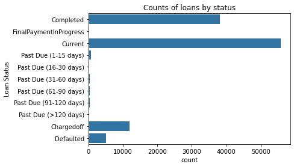

```python
sb.countplot(data = df, y= 'LoanStatus', color = sb.color_palette()[0], order = dstatus)
plt.ylabel('Loan Status')
plt.title('Counts of loans by status');
```

#### The loan status is the main feature, the loans at risk counts are very important. So, will focus on the past due loans.

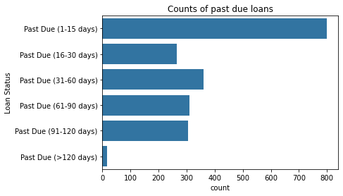

```python
#As this is the main feature I'll pay more attention to past due categories
df_pd = df.query("LoanStatus in {}".format(pd_list))
sb.countplot(data = df_pd, y= 'LoanStatus', color = sb.color_palette()[0], order = pd_list)
plt.ylabel('Loan Status')
plt.title('Counts of past due loans');
```

#### Apparently we have more than 2000 past due loans, with about 1000 are past due for more than a month.

### Borrower APR

```python
df.describe()['BorrowerAPR']
```

```
count    113036.000000
mean          0.218981
std           0.080484
min           0.006530
25%           0.156290
50%           0.209840
75%           0.283860
max           0.512290
Name: BorrowerAPR, dtype: float64
```

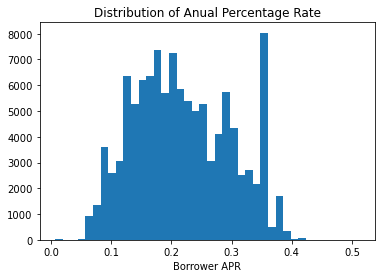

```python
plt.hist(data = df[df.BorrowerAPR.isnull()== False], x= 'BorrowerAPR', bins = 40)
plt.xlabel('Borrower APR')
plt.title('Distribution of Anual Percentage Rate');
```

- The annual percentage rate varies from about 0.007 to 0.512 with a mean of 0.219.
- There are multiple peaks around 0.17, 0.21 and 0.36 with most of values concentrated around the mean while the mode is around 0.36.

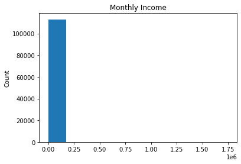

```python
#Now lets explore the other variables
plt.hist(data = df, x= 'StatedMonthlyIncome')
plt.title('Monthly Income')
plt.ylabel('Count');
```

#### With income having most of the values at the left, while there are very large values with rare occurences, we need to plot their logs to have more insights

```python
df.describe()['StatedMonthlyIncome']
```

```
count    1.130610e+05
mean     5.605252e+03
std      7.495728e+03
min      0.000000e+00
25%      3.200000e+03
50%      4.666667e+03
75%      6.825000e+03
max      1.750003e+06
Name: StatedMonthlyIncome, dtype: float64
```

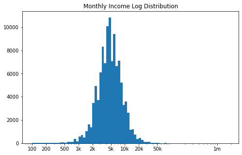

```python
#First let's take the monthly income
log_binsize = 0.05
bins = 10 ** np.arange(2, np.log10(df['StatedMonthlyIncome'].max())+log_binsize, log_binsize)
inc_ticks = [100, 200, 500, 1e3, 2e3, 5e3, 1e4, 2e4, 5e4, 1e6]
inc_labels = [100, 200,500, '1k', '2k', '5k', '10k', '20k', '50k', '1m']
plt.figure(figsize=[8, 5])
plt.hist(data = df, x = 'StatedMonthlyIncome', bins = bins)
plt.title('Monthly Income Log Distribution')
plt.xscale('log')
plt.xticks(inc_ticks, inc_labels );
```

#### Apparently the monthly income has a log normal distribution around a mean of about 5k, and most of the values are between 1k and 20k dollars.

```python
#We need to get more insights about the outliers
df[df.StatedMonthlyIncome <100]
```

|  | Term | LoanStatus | BorrowerAPR | Occupation | EmploymentStatus | IsBorrowerHomeowner | StatedMonthlyIncome | LoanOriginalAmount | ProsperScore | MonthlyLoanPayment | IncomeVerifiable | ListingCategory | Year | LStatus |
| --- | --- | --- | --- | --- | --- | --- | --- | --- | --- | --- | --- | --- | --- | --- |
| 78 | 36 | Chargedoff | 0.18454 | Realtor | Full-time | True | 0.000000 | 4800 | NaN | 171.13 | False | Business | 2008 | Defaulted/ChargedOff |
| 100 | 36 | Chargedoff | 0.35356 | Other | Not employed | False | 0.000000 | 4000 | 3.0 | 172.76 | False | Household Expenses | 2013 | Defaulted/ChargedOff |
| 108 | 36 | Completed | 0.28320 | Executive | Full-time | False | 0.000000 | 14000 | NaN | 564.07 | False | Debt Consolidation | 2008 | Completed |
| 125 | 36 | Current | 0.35643 | Other | Not employed | False | 0.000000 | 5000 | 5.0 | 217.74 | False | Other | 2011 | Current |
| 146 | 36 | Completed | 0.09939 | Unspecified | Not available | False | 0.083333 | 4000 | NaN | 127.66 | False | Not Available | 2006 | Completed |
| ... | ... | ... | ... | ... | ... | ... | ... | ... | ... | ... | ... | ... | ... | ... |
| 113686 | 36 | Completed | 0.21588 | Other | Full-time | False | 0.000000 | 14900 | NaN | 560.21 | False | Not Available | 2007 | Completed |
| 113761 | 60 | Current | 0.16151 | Other | Not employed | False | 0.000000 | 7000 | 8.0 | 162.33 | False | Debt Consolidation | 2012 | Current |
| 113766 | 36 | Current | 0.12427 | Other | Not employed | False | 0.000000 | 4500 | 8.0 | 144.44 | False | Vacation | 2012 | Current |
| 113767 | 36 | Chargedoff | 0.36945 | Other | Self-employed | False | 0.000000 | 5000 | NaN | 224.77 | False | Business | 2008 | Defaulted/ChargedOff |
| 113803 | 36 | Defaulted | 0.11293 | Sales - Retail | Self-employed | True | 0.000000 | 5000 | NaN | 161.10 | False | Other | 2008 | Defaulted/ChargedOff |

1758 rows × 14 columns

```python
#Many borrowers with less than 1k dollars are not employed and this might be logic.
low_income = df[(df.StatedMonthlyIncome <100) & (df.EmploymentStatus != 'Not employed')]
low_income
```

|  | Term | LoanStatus | BorrowerAPR | Occupation | EmploymentStatus | IsBorrowerHomeowner | StatedMonthlyIncome | LoanOriginalAmount | ProsperScore | MonthlyLoanPayment | IncomeVerifiable | ListingCategory | Year | LStatus |
| --- | --- | --- | --- | --- | --- | --- | --- | --- | --- | --- | --- | --- | --- | --- |
| 78 | 36 | Chargedoff | 0.18454 | Realtor | Full-time | True | 0.000000 | 4800 | NaN | 171.13 | False | Business | 2008 | Defaulted/ChargedOff |
| 108 | 36 | Completed | 0.28320 | Executive | Full-time | False | 0.000000 | 14000 | NaN | 564.07 | False | Debt Consolidation | 2008 | Completed |
| 146 | 36 | Completed | 0.09939 | Unspecified | Not available | False | 0.083333 | 4000 | NaN | 127.66 | False | Not Available | 2006 | Completed |
| 226 | 36 | Completed | 0.11749 | Other | Full-time | True | 0.083333 | 1000 | NaN | 32.27 | False | Not Available | 2007 | Completed |
| 576 | 36 | Completed | 0.10505 | Homemaker | Retired | False | 0.083333 | 1500 | NaN | 47.94 | False | Not Available | 2007 | Completed |
| ... | ... | ... | ... | ... | ... | ... | ... | ... | ... | ... | ... | ... | ... | ... |
| 113608 | 60 | Chargedoff | 0.24252 | Sales - Commission | Employed | False | 0.000000 | 8000 | 6.0 | 220.91 | False | Debt Consolidation | 2011 | Defaulted/ChargedOff |
| 113626 | 36 | Completed | 0.17722 | Unspecified | Not available | False | 0.083333 | 25000 | NaN | 891.32 | False | Not Available | 2006 | Completed |
| 113686 | 36 | Completed | 0.21588 | Other | Full-time | False | 0.000000 | 14900 | NaN | 560.21 | False | Not Available | 2007 | Completed |
| 113767 | 36 | Chargedoff | 0.36945 | Other | Self-employed | False | 0.000000 | 5000 | NaN | 224.77 | False | Business | 2008 | Defaulted/ChargedOff |
| 113803 | 36 | Defaulted | 0.11293 | Sales - Retail | Self-employed | True | 0.000000 | 5000 | NaN | 161.10 | False | Other | 2008 | Defaulted/ChargedOff |

993 rows × 14 columns

```python
#Now I'll check the values higher than 50k
df[(df.StatedMonthlyIncome >50000)]
```

|  | Term | LoanStatus | BorrowerAPR | Occupation | EmploymentStatus | IsBorrowerHomeowner | StatedMonthlyIncome | LoanOriginalAmount | ProsperScore | MonthlyLoanPayment | IncomeVerifiable | ListingCategory | Year | LStatus |
| --- | --- | --- | --- | --- | --- | --- | --- | --- | --- | --- | --- | --- | --- | --- |
| 4691 | 36 | Completed | 0.12528 | Attorney | Employed | True | 75000.000000 | 13000 | 8.0 | 417.89 | True | Debt Consolidation | 2012 | Completed |
| 8066 | 36 | Completed | 0.35643 | Police Officer/Correction Officer | Employed | True | 416666.666667 | 2000 | 4.0 | 87.10 | True | Debt Consolidation | 2011 | Completed |
| 8870 | 36 | Chargedoff | 0.12700 | Other | Not available | True | 208333.333333 | 12500 | NaN | 415.18 | True | Not Available | 2006 | Defaulted/ChargedOff |
| 11312 | 36 | Completed | 0.08684 | Realtor | Full-time | False | 75000.000000 | 3000 | NaN | 94.01 | True | Not Available | 2007 | Completed |
| 11835 | 36 | Current | 0.13697 | Executive | Employed | True | 52500.000000 | 15000 | 9.0 | 490.30 | True | Debt Consolidation | 2012 | Current |
| ... | ... | ... | ... | ... | ... | ... | ... | ... | ... | ... | ... | ... | ... | ... |
| 105248 | 36 | Current | 0.20562 | Other | Employed | True | 70833.333333 | 25000 | 5.0 | 889.45 | True | Debt Consolidation | 2014 | Current |
| 108154 | 36 | Current | 0.14857 | Executive | Employed | True | 52500.000000 | 21500 | 9.0 | 714.42 | True | Debt Consolidation | 2013 | Current |
| 109043 | 36 | Current | 0.18214 | Executive | Employed | True | 68750.000000 | 25000 | 7.0 | 861.62 | True | Debt Consolidation | 2013 | Current |
| 111265 | 60 | Completed | 0.20593 | Executive | Employed | False | 108750.000000 | 12765 | 9.0 | 325.47 | True | Debt Consolidation | 2013 | Completed |
| 113270 | 36 | Current | 0.22712 | Other | Employed | False | 394400.000000 | 2000 | 6.0 | 73.30 | True | Other | 2013 | Current |

81 rows × 14 columns

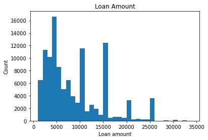

```python
#Now let's look into the loan amount
bins = np.arange(1000, 35000, 1000)
plt.hist(data = df, x= 'LoanOriginalAmount', bins= bins)
plt.title('Loan Amount')
plt.ylabel('Count')
plt.xlabel('Loan amount');
```

#### Most of the loan amounts are less than or equal 25k, with very large number of loans with values from 1000, 5000, and arround 15000 and 10000.

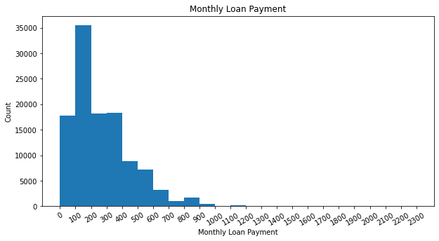

```python
#Now for monthly loan payment
plt.figure(figsize =(10,5))
bins = np.arange(0, df.MonthlyLoanPayment.max() + 100, 100)
plt.hist(data = df, x= 'MonthlyLoanPayment', bins= bins)
plt.title('Monthly Loan Payment')
plt.ylabel('Count')
plt.xlabel('Monthly Loan Payment')
plt.xticks(bins , bins.astype(int), rotation = 30);
```

#### Most monthly loan payments are less than 400, with a clear peak between 100 and 200.

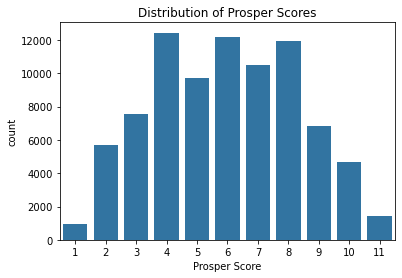

```python
#Distribution of prosper score
sb.countplot(data = df[df.ProsperScore.isnull() == False], x= 'ProsperScore', color = clr)
plt.xticks([0,1,2,3,4,5,6,7,8,9,10],['1','2','3','4','5','6','7','8','9','10','11'])
plt.title('Distribution of Prosper Scores')
plt.xlabel('Prosper Score');
```

- Surprisingly there are loans with score more than 10 (The maximum mentioned in the data dictionary).
- The scores seem to be in general normally distributed arround 6.

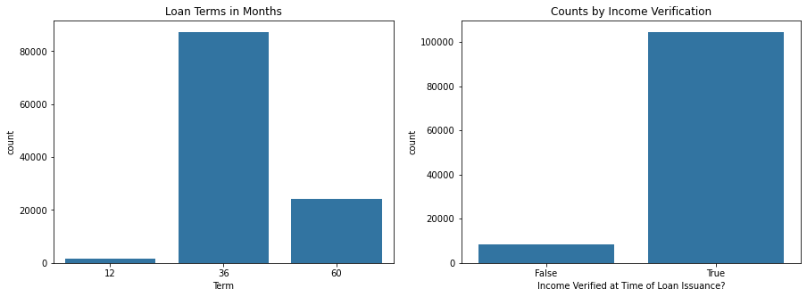

```python
#Now let's explore the categorical variables, starting with the loan terms and income verification
clr = sb.color_palette()[0]
plt.figure(figsize = (15,5))
plt.subplot(1,2,1)
sb.countplot(data = df, x= 'Term', color=clr)
plt.title('Loan Terms in Months')
plt.subplot(1,2,2)
sb.countplot(data = df, x = 'IncomeVerifiable', color = clr)
plt.title('Counts by Income Verification')
plt.xlabel('Income Verified at Time of Loan Issuance?');
```

- Most loans span for 3 years (more than 80000), and a large number spans for 5 years while the least number lasts for one year.
- Most borrowers' incomes were verified.

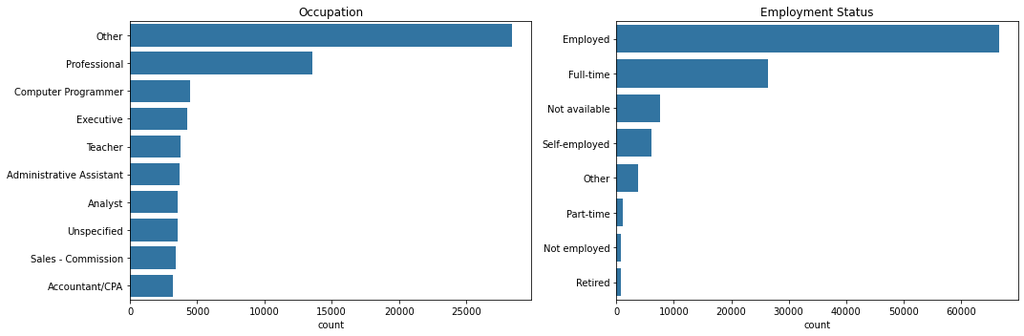

```python
#Now for occupation and employment status

plt.figure(figsize= [15, 5])

#For occupation we will limit the plot to top 10 as it has many values
plt.subplot(1,2,1)
occ_order = df.Occupation.value_counts()[:10].index
sb.countplot(data = df, y= 'Occupation', color = clr, order = occ_order)
plt.title('Occupation')
plt.ylabel('')
plt.subplot(1,2,2)
sb.countplot(data = df, y= 'EmploymentStatus', color = clr, order = df.EmploymentStatus.value_counts().index)
plt.title('Employment Status')
plt.ylabel('')
plt.tight_layout();
```

#### Most of the borrowers occupations are not classified (other) and most of them are employed

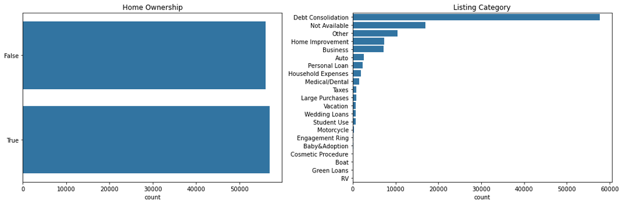

```python
plt.figure(figsize= [15, 5])
plt.subplot(1,2,1)
sb.countplot(data = df, y= 'IsBorrowerHomeowner', color = clr)
plt.title('Home Ownership')
plt.ylabel('')
plt.subplot(1,2,2)
sb.countplot(data = df, y= 'ListingCategory', color = clr, order = df.ListingCategory.value_counts().index)
plt.title('Listing Category')
plt.ylabel('')
plt.tight_layout();
```

- The borrowers owning homes are slightly more than those who doesn't.
- Most loans are debit consilidations. Many of them are for home improvement, business and auto.

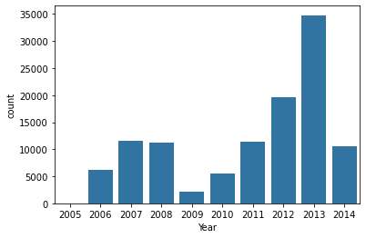

```python
#Now for the date, I'll check the loans counts by year
year_ord = df.Year.sort_values().unique()
sb.countplot(data = df, x='Year', color = clr, order = year_ord);
```

#### As both 2005 and 2014 are not complete, considering the other years, we find a drop in the loans count in 2009 then a +ve trend since then.

### Discuss the distribution(s) of your variable(s) of interest. Were there any unusual points? Did you need to perform any transformations?

- I explored the loan status by plotting all counts, then focused on loans at risk (which are past due).
- Borrower APR has multiple peaks, but the most of them is around 0.36.

## Bivariate Exploration

```python
#As dealing with categorical variable is different from quantitative ones, I'll create a list of each
num_vars = ['StatedMonthlyIncome', 'LoanOriginalAmount','BorrowerAPR','ProsperScore', 'MonthlyLoanPayment']
cat_vars = ['Term', 'LStatus', 'Occupation', 'EmploymentStatus', 'IsBorrowerHomeowner', 'ListingCategory','year','IncomeVerifiable']
```

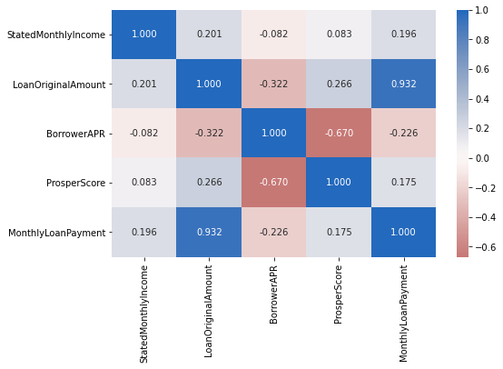

```python
#First I need to check the correlation coefficients among numeric variables
plt.figure(figsize = [8, 5])
sb.heatmap(df[num_vars].corr(), annot = True, fmt = '.3f',
           cmap = 'vlag_r', center = 0);
```

#### From the above figure we notice the following:

- A strong positive correlation between the loan amount and the monthly payment.
- A negative correlation between borrower APR and prosper score. This makes sence as the rate decreased for less risky loans.

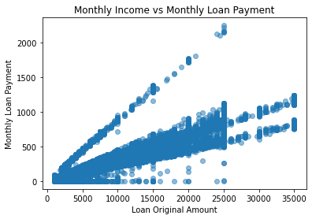

```python
#So, let's plot the monthly income against the monthly payment
plt.scatter(data = df, x = 'LoanOriginalAmount',y= 'MonthlyLoanPayment', alpha = 0.5)
plt.xlabel('Loan Original Amount')
plt.ylabel('Monthly Loan Payment')
plt.title ('Monthly Income vs Monthly Loan Payment');
```

- There appears three linear relations between the loan amount and the monthly payment, which seems logic for the different terms (12, 36 and 60) months and the variations are due to the interest rates.
- What is strange here is the points with very low monthly payments (near zero) even with large loan amounts.

```python
df[df.MonthlyLoanPayment ==0].LStatus.value_counts()
```

```
Completed               800
Defaulted/ChargedOff    131
Current                   4
High Risk                 0
Low Risk                  0
Name: LStatus, dtype: int64
```

#### The counts are not very high and I will not delete these records, but will take this into consideration.

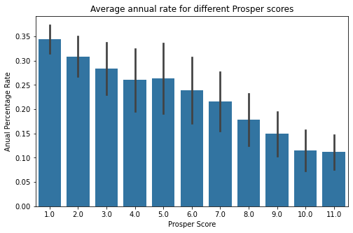

```python
#To get more insight into the correlation between prosper score and APR, will plot the mean percentage for each score.
plt.figure(figsize = (8,5))
sb.barplot(data = df, x = 'ProsperScore', y = 'BorrowerAPR', color = clr, ci = 'sd')
plt.title('Average annual rate for different Prosper scores')
plt.xlabel('Prosper Score')
plt.ylabel('Anual Percentage Rate');
```

#### It is clear that the percentage decreases as the score increases (indicating lower risk), with an exception at score 5 that has a little more rate than 4.

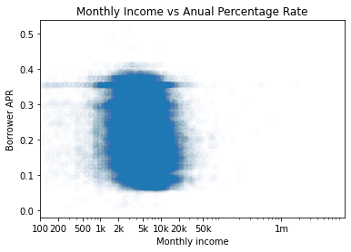

```python
#Now, let's plot the monthly income against the APR
plt.scatter(data = df, x = 'StatedMonthlyIncome',y= 'BorrowerAPR', alpha = 0.01)
plt.xlabel('Monthly income')
plt.ylabel('Borrower APR')
plt.title ('Monthly Income vs Anual Percentage Rate')
plt.xscale('log')
plt.xticks(inc_ticks, inc_labels );
```

#### The monthly income doesn't affect the annual percentage rate.

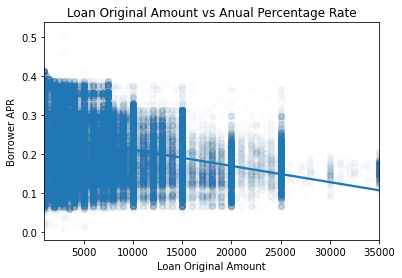

```python
#let's see if the loan ammount affects the APR
sb.regplot(data = df, x = 'LoanOriginalAmount',y= 'BorrowerAPR', scatter_kws={'alpha':0.01})
plt.xlabel('Loan Original Amount')
plt.ylabel('Borrower APR')
plt.title ('Loan Original Amount vs Anual Percentage Rate');
```

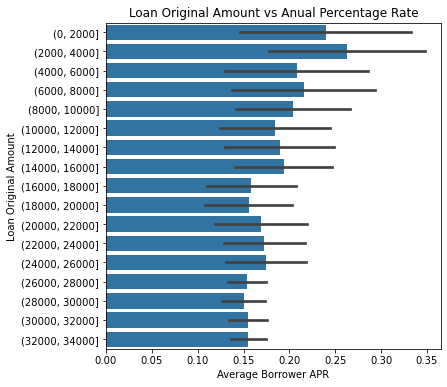

```python
#To get more insight, I'd cut the loan amounts and get the average rate for each range
ranges = list(np.arange(0,36000, 2000))
df['AmountRange'] = pd.cut(df['LoanOriginalAmount'], bins = ranges)
plt.figure(figsize = (6,6))
sb.barplot(data = df, y = 'AmountRange',x= 'BorrowerAPR', color = clr, ci = 'sd')
plt.ylabel('Loan Original Amount')
plt.xlabel('Average Borrower APR')
plt.title ('Loan Original Amount vs Anual Percentage Rate');
```

#### Low amounts have high rates with large standard deviation, while large amounts have small rates with low standard deviation.

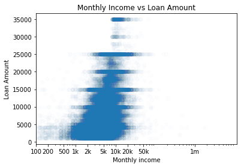

```python
#Now, let's plot the monthly income against the loan amount
plt.scatter(data = df, x = 'StatedMonthlyIncome',y= 'LoanOriginalAmount', alpha = 0.01)
plt.xlabel('Monthly income')
plt.ylabel('Loan Amount')
plt.title ('Monthly Income vs Loan Amount')
plt.xscale('log')
plt.xticks(inc_ticks, inc_labels);
```

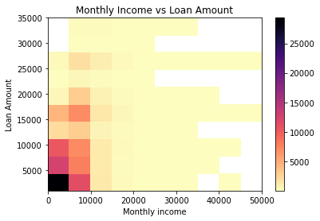

```python
#For better insight I'll exclude those with monthly income more than 50k, and will show a heat map
plt.hist2d(data = df[df.StatedMonthlyIncome <=50000], x= 'StatedMonthlyIncome', y = 'LoanOriginalAmount' ,
           cmin=5, cmap = 'magma_r' )
plt.colorbar()
plt.xlabel('Monthly income')
plt.ylabel('Loan Amount')
plt.title ('Monthly Income vs Loan Amount');
```

#### Most of loans are less than 20000 and with monthly income less than 10000. For lower income, the counts of loans decreases when loans amounts increases, but for higher income, counts are nearly the same.

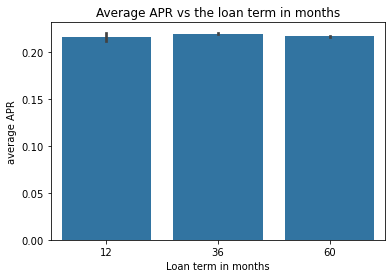

```python
#Now lets see the relation between the loan term and the APR
sb.barplot(data = df, x = 'Term', y= 'BorrowerAPR', color = clr)
plt.title ('Average APR vs the loan term in months')
plt.xlabel('Loan term in months')
plt.ylabel('average APR');
```

#### The loan term doesn't affect the annual rate.

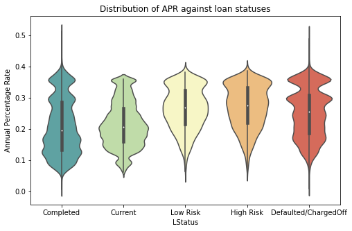

```python
#Now let's see the annual rate against the loan statuses
plt.figure(figsize=(8,5))
sb.violinplot(data = df, x = 'LStatus', y= 'BorrowerAPR', palette = 'Spectral_r')
plt.title ('Distribution of APR against loan statuses')
plt.xlabel('LStatus')
plt.ylabel('Annual Percentage Rate');
```

#### The density of defaulted loans increases at high rates, and so are loans at risk, while the density of current and completed loans is higher at small rates. The internal box plots assure this.

```python
#I would like to check the quartiles of data
df.describe()
```

|  | BorrowerAPR | StatedMonthlyIncome | LoanOriginalAmount | ProsperScore | MonthlyLoanPayment |
| --- | --- | --- | --- | --- | --- |
| count | 113036.000000 | 1.130610e+05 | 113061.000000 | 83982.000000 | 113061.000000 |
| mean | 0.218981 | 5.605252e+03 | 8315.054838 | 5.952871 | 271.942047 |
| std | 0.080484 | 7.495728e+03 | 6236.987928 | 2.373897 | 192.549040 |
| min | 0.006530 | 0.000000e+00 | 1000.000000 | 1.000000 | 0.000000 |
| 25% | 0.156290 | 3.200000e+03 | 4000.000000 | 4.000000 | 130.950000 |
| 50% | 0.209840 | 4.666667e+03 | 6300.000000 | 6.000000 | 217.370000 |
| 75% | 0.283860 | 6.825000e+03 | 12000.000000 | 8.000000 | 370.570000 |
| max | 0.512290 | 1.750003e+06 | 35000.000000 | 11.000000 | 2251.510000 |

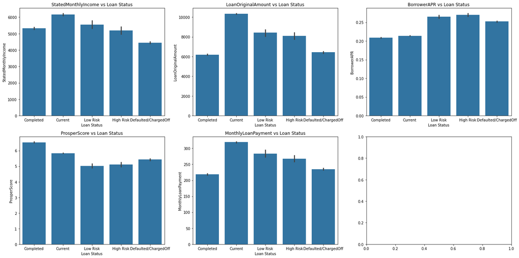

```python
#Now I want to check the numeric variables against the loan status categories.
plt.subplots(2,3,figsize = (20,10))
for i in range(0,5):
    plt.subplot(2,3,i+1)
    sb.barplot(data = df, x = 'LStatus', y= num_vars[i], color = clr, order = lstatus)
    plt.title(num_vars[i] +' vs Loan Status')
    plt.xlabel('Loan Status')
    plt.ylabel(num_vars[i])
    plt.tight_layout()
```

- Defaulted loan has slightly lower income than completed ones, and current loans have higher income than other statuses.
- The loans amounts for current loans are generally larger than other loans, the low risk loans come next, then high risk while both completed and defaulted loans have nearly same average
- Defaulted loans have higher rates than completed ones. Also loans at risk have higher rates than current loans.
- Prosper score for completed and current loans is higher than that of loans at risk and defaulted loans.
- The monthly payment for currently opened loans (current and loans at risk) is in general higher than closed ones.

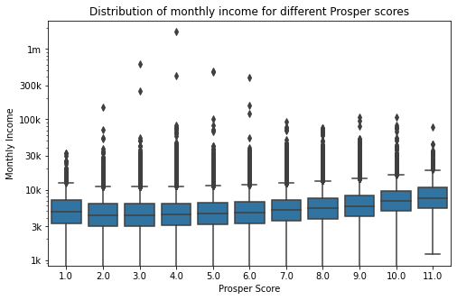

```python
#Now, let's plot the monthly income against prosper score, and as the income has outliers that might affect the mean,
# I'll use point plot and log scale.
plt.figure(figsize = (8,5))
sb.boxplot(data = df, x = 'ProsperScore', y = 'StatedMonthlyIncome', color = clr)
plt.yscale('log')
plt.title('Distribution of monthly income for different Prosper scores')
plt.xlabel('Prosper Score')
plt.ylabel('Monthly Income')
plt.yticks([1000,3000, 10000, 30000, 100000, 300000, 1000000],['1k','3k','10k','30k','100k', '300k','1m']);
```

#### Increase in the income may lead to increase in the prosper score.

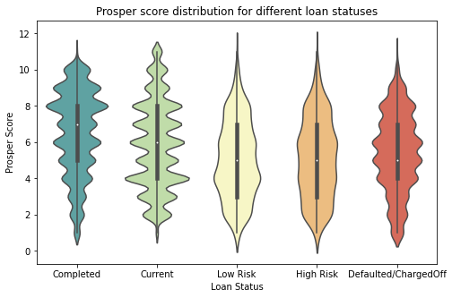

```python
plt.figure(figsize = (8,5))
sb.violinplot(data = df, x= 'LStatus', y = 'ProsperScore', palette = 'Spectral_r' )
plt.title ('Prosper score distribution for different loan statuses')
plt.ylabel('Prosper Score')
plt.xlabel('Loan Status');
```

#### In general defaulted loans and loans at risk had lower prosper score than completed and current loans.

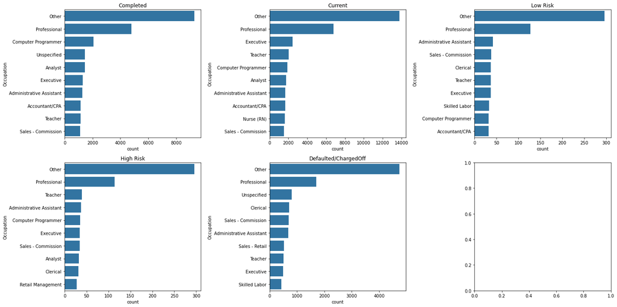

```python
#Now we will check the relation between loan status and occupations, I will get the top 10 occupations for each status
plt.subplots(2,3,figsize = (20,10))

for i in range(5):   #index of the status list
    plt.subplot(2,3,i+1)
    df_sub = df[df.LStatus == lstatus[i]]
    occ_ord = df_sub.Occupation.value_counts()[:10].index
    sb.countplot(data = df_sub, y = 'Occupation', order = list(occ_ord), color = clr)
    plt.title(lstatus[i])
    plt.tight_layout()
```

#### As most of the borrowers have their occupation either "Other" or "Professional", it's logic to see them at top od all statuses. However, it is apparent that the ratio of "Other" and "Unspecified" occupations are larger in Defaulted and Charged Off loans. So, it is important to identify the occupation of the borrower.

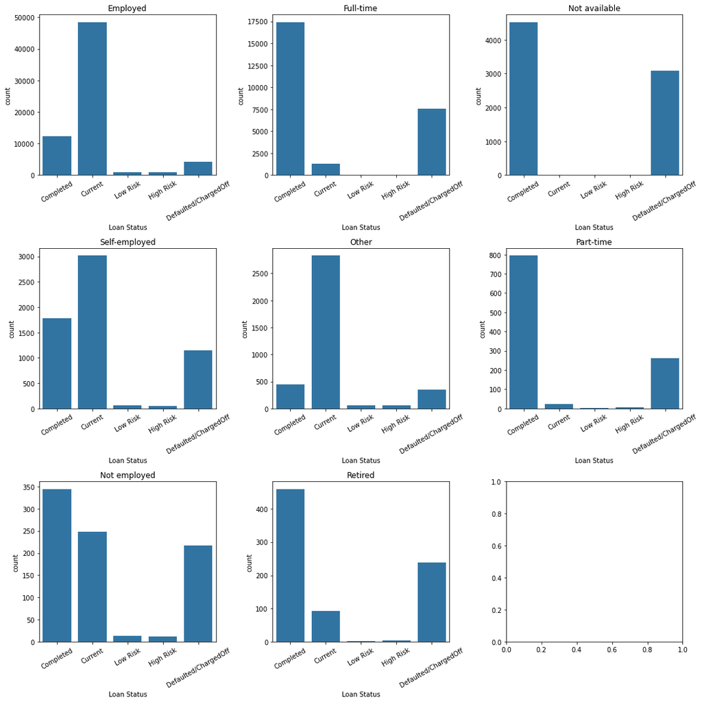

```python
#For Employment Status, I would like to see the distribution of loan statuses for each employment status
plt.subplots(3,3,figsize = (15,15))
estatus = list(df.EmploymentStatus.value_counts().index)
for i in range(8):   #index of the status list
    plt.subplot(3,3,i+1)
    df_sub = df[df.EmploymentStatus == estatus[i]]
    sb.countplot(data = df_sub, x = 'LStatus', order = lstatus, color = clr)
    plt.title(estatus[i])
    plt.xlabel('Loan Status')
    plt.xticks(rotation = 30)
    plt.tight_layout()
```

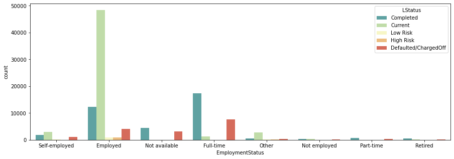

```python
plt.figure(figsize = (15,5))
sb.countplot(data = df, x = 'EmploymentStatus', hue = 'LStatus', palette = 'Spectral_r', hue_order = lstatus);
```

#### The largest number of defaulted and completed loans is associated to the "Full-time" employment, while currently there is a low number of loans for this status. Most of current loans are for borrowers with "Employed" status.

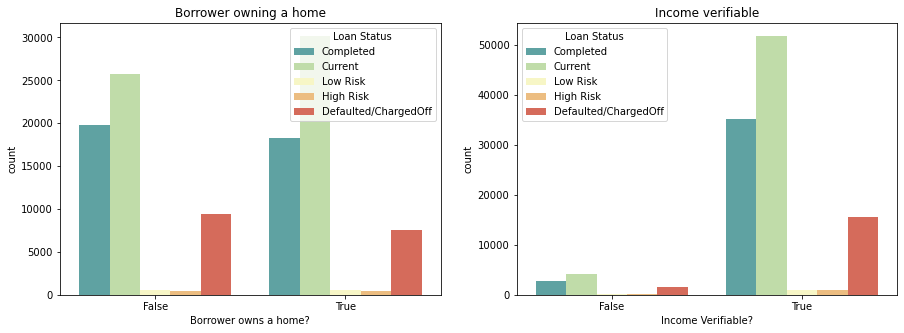

```python
#Let's now check the loan status grouped by the status of owning a home
plt.figure(figsize = (15,5))
plt.subplot(1,2,1)
ax = sb.countplot(data = df, hue= 'LStatus', x = 'IsBorrowerHomeowner',  hue_order = lstatus, palette = 'Spectral_r')
plt.xlabel( 'Borrower owns a home?')
ax.legend(title = "Loan Status")
plt.title('Borrower owning a home');
plt.subplot(1,2,2)
ax = sb.countplot(data = df, hue= 'LStatus', x = 'IncomeVerifiable', hue_order = lstatus, palette = 'Spectral_r')
plt.xlabel( 'Income Verifiable?')
ax.legend(title = "Loan Status")
plt.title('Income verifiable');
```

- Borrowers not owning homes are more in completed and defaulted (closed) loans, while borrowers owning homes are more in open loans.
- In general verified income counts are much larger than unverified income counts. The distribution of statuses for both is similar.

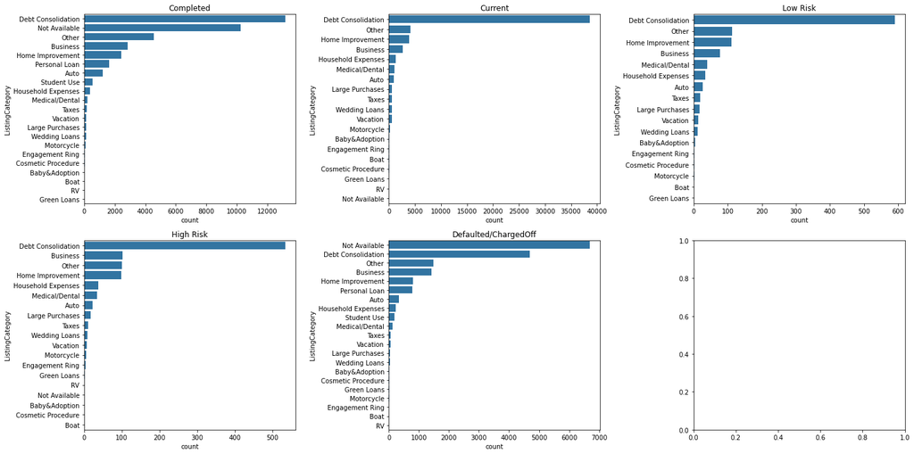

```python
#let's see the listing categories against the loan status
plt.subplots(2,3,figsize = (20,10))

for i in range(5):   #index of the status list
    plt.subplot(2,3,i+1)
    df_sub = df[df.LStatus == lstatus[i]]
    lc_ord = df_sub.ListingCategory.value_counts().index
    sb.countplot(data = df_sub, y = 'ListingCategory', order = list(lc_ord), color = clr)
    plt.title(lstatus[i])
    plt.tight_layout()
```

#### As most of the loans are for debit consolidation, it is logic to be at top of the charts. However, the defaulted loans have the "Not Available" at the top. So the listing catogory should be specified.

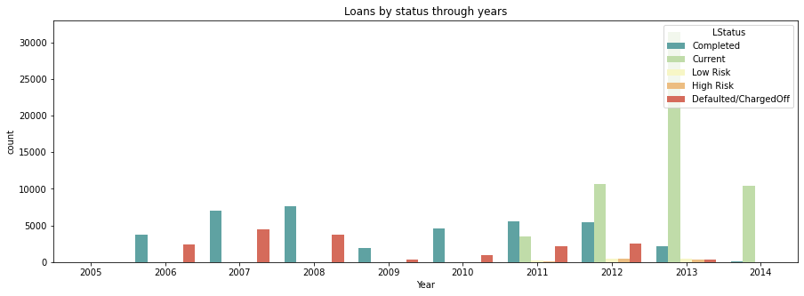

```python
#Now let's see the loan status distribution through years
plt.figure(figsize = (15,5))
sb.countplot(data = df, x='Year', hue = 'LStatus', palette = 'Spectral_r', order = year_ord)
plt.title('Loans by status through years');
```

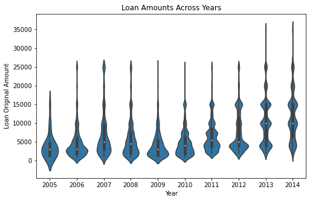

```python
plt.figure(figsize = (8,5))
sb.violinplot(data = df, x = 'Year', y = 'LoanOriginalAmount', order = year_ord, color = clr)
plt.title('Loan Amounts Across Years')
plt.ylabel('Loan Original Amount');
```

#### There is a noticed increase in loan amounts for the last two years.